# SOC-GA 2332 Intro to Stats Lab 5 Solution

Wenhao Jiang

10/06/2023

```r
knitr::opts_chunk$set(echo = TRUE)

library(pacman)
p_load(tidyverse, psych, gridExtra, foreign, stargazer, ggcorrplot, kableExtra)
```

### Part 1 Exercise:

1. Simulate the data with the same relationship as specified above, only **changing the residual term from having a sd = 10 to sd = 50**. Follow the steps demonstrated above, create a dataframe and fit an OLS model to your simulated data. Create a scatterplot of your data and post the plot to Slack. *Note:* Remember to `set.seed()`!
2. Then, using the formula we have learned in the lecture, hand-code the following statistics and post your answer to Slack:
1. The value of TSS
2. $R^2$
3. Verify that $R^2$ = $\rho^2$
4. $se_{\beta_1}$
5. Construct the 95% confidence interval for $\beta_1$ (You can use the $\beta_1$ value reported in your OLS modeling result)

> The **sum of square error (SSE)** for Y is the sum of square errors for the fitted OLS model: $SSE = \sum\epsilon^2 = \sum(y - \hat y)^2$  
> The **total sum of sqaures (TSS)** for Y is the sum of square errors for the baseline OLS model (the “null model”) that predict the value of Y without any X (the mean of Y, $\overline Y$, is used in the null model): $TSS = \sum(y - \overline y)^2$  
> **R-squared** (coefficient of determination) is the proportional reduction in squared error when fitted with the OLS model in comparison with the null model: $R^2 = \frac{TSS - SSE}{TSS}$  
> The **mean square error (MSE)**: $MSE = \frac{SSE}{n-2}$  
> The **standard error of $\beta_1$ in bivariant OLS** regression: $se_{\beta_1} = \sqrt{\frac{MSE}{\sum{(x -\overline x)^2}}}$
3. Compare the scatterplot, the estimated $\beta_0$ and $\beta_1$, the $R^2$, and the $se_{\beta_1}$ in the demo OLS model output and your own simulated data model output, what do you observe? Why?

```r
set.seed(1234)
# Simulate IV (edu level)
edu2 <- rpois(300, lambda = 6) #rpois: Random Poisson Distribution with parameter lamda
# Simulate DV
earn2 <- 10 + 6*edu2 + rnorm(300, 0, 50) # add a random error using rnorm()

# Combine dataframe
df_exercise <- tibble(x_edu = edu2, y_earn = earn2)

# Fit model
m_simu_exercise <- lm(y_earn ~ x_edu, data = df_exercise)
summary(m_simu_exercise)
```

```
##
## Call:
## lm(formula = y_earn ~ x_edu, data = df_exercise)
##
## Residuals:
##     Min      1Q  Median      3Q     Max
## -167.42  -32.25   -0.62   33.37  146.08
##
## Coefficients:
##             Estimate Std. Error t value Pr(>|t|)
## (Intercept)   -1.402      7.839  -0.179    0.858
## x_edu          8.255      1.222   6.758 7.38e-11 ***
## ---
## Signif. codes:  0 '***' 0.001 '**' 0.01 '*' 0.05 '.' 0.1 ' ' 1
##
## Residual standard error: 51.35 on 298 degrees of freedom
## Multiple R-squared:  0.1329, Adjusted R-squared:   0.13
## F-statistic: 45.66 on 1 and 298 DF,  p-value: 7.38e-11
```

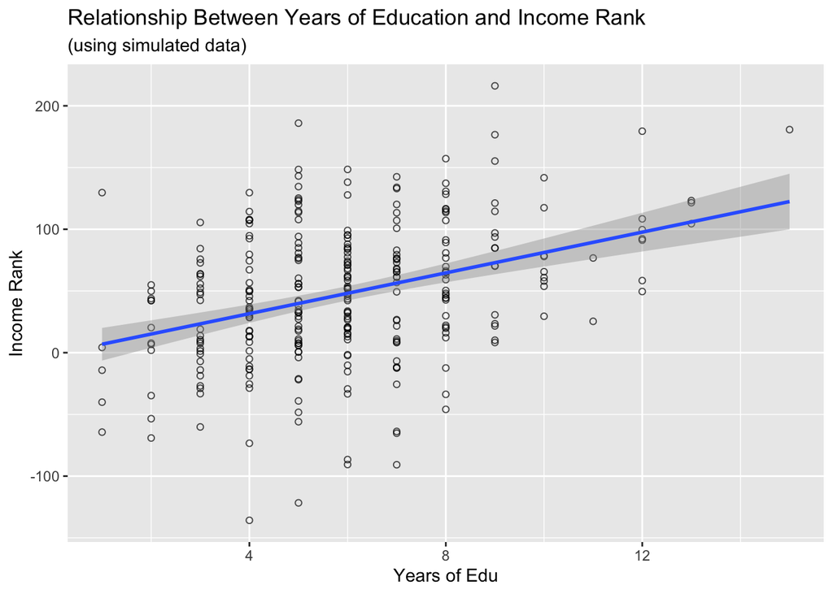

```r
# Scatterplot
df_exercise %>%
  ggplot(aes(x = x_edu, y = y_earn)) +
  geom_point(shape = 1, alpha = 0.7) +
  geom_smooth(method = "lm") +
  labs(title = "Relationship Between Years of Education and Income Rank",
       subtitle = "(using simulated data)",
       x = "Years of Edu",
       y = "Income Rank")
```

```r
# Create 3 variables: x_mean, y_mean, fitted_y
df_exercise <- df_exercise %>%
  mutate(x_mean = mean(df_exercise$x_edu),
         y_mean = mean(df_exercise$y_earn),
         y_fitted = -1.402 + 8.255*x_edu)

#TSS
TSS <- (df_exercise$y_earn - df_exercise$y_mean)^2 %>% sum()
TSS
```

```
## [1] 906210.7
```

```r
# R-squared
SSE <- (df_exercise$y_earn - df_exercise$y_fitted)^2 %>% sum()
R_sq <- (TSS - SSE)/TSS
R_sq
```

```
## [1] 0.1328737
```

```r
# Rho
rho = cor(df_exercise$y_earn, df_exercise$x_edu)
rho^2 # is equal to R_sq
```

```
## [1] 0.1328737
```

```r
# se_beta1
MSE <- SSE/(nrow(df_exercise) - 2)
denomi <- (df_exercise$x_edu - df_exercise$x_mean)^2 %>% sum()
#Or the denominator is (n-1)sd_x^2: (nrow(df_exercise) - 1)*sd(df_exercise$x_edu)^2
se_beta1 <- sqrt(MSE/denomi)
se_beta1
```

```
## [1] 1.221629
```

```r
# CI of se_beta1:
#upper: 8.255 + 1.96*1.222 = 10.65012
#lower: 8.255 - 1.96*1.222 = 5.85988
```